# 2014-2017 Variable Selection

Konner Macias

May 23, 2018

Read in data

```r
df <- read.csv("NBA-2014-2017.csv", stringsAsFactors = FALSE)
df[is.na(df)] <- 0
```

Look at correlation between variables

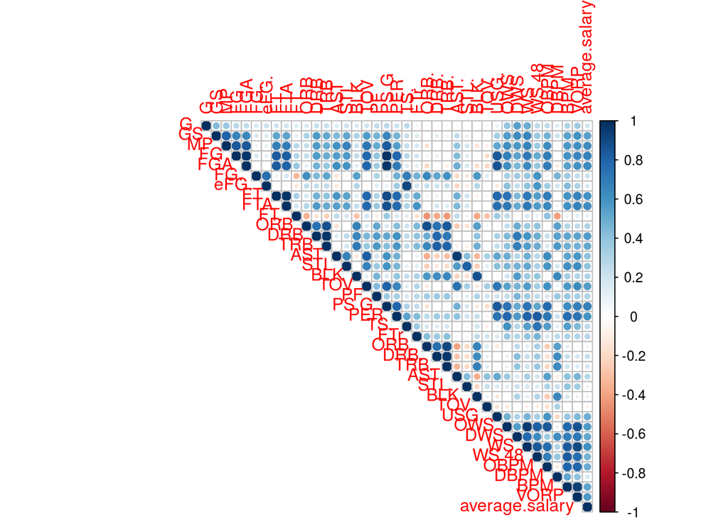

```r
library(corrplot)
M <- cor(df[-c(1,2,3,43)]) # exclude name, team, position, and year for correlation
corrplot(M,method = "circle", type = "upper")
```

Which variables correlate the most with average salary?

```r
sort(M[39,],decreasing = TRUE)
```

```
## average.salary             FG           PS.G            FGA            FTA
##     1.00000000     0.67634213     0.67122051     0.63645972     0.62605027
##             MP             WS             FT            PER           VORP
##     0.62006760     0.60871854     0.60209330     0.59270021     0.56522497
##            DRB            OWS            TOV             GS            BPM
##     0.56204729     0.56018772     0.55559481     0.54662067     0.52896035
##            DWS            TRB           USG.           OBPM          WS.48
##     0.51406142     0.51086466     0.49071954     0.49043466     0.46794745
##            AST            STL             PF            ORB            BLK
##     0.40914340     0.40201724     0.30904415     0.30786242     0.30194669
##           AST.            FTr            TS.           DRB.            FG.
##     0.28325750     0.27845995     0.26406697     0.23267021     0.21357788
##              G           TRB.           DBPM           eFG.            FT.
##     0.18858519     0.18661958     0.17358227     0.16497163     0.10418145
##           BLK.           STL.           ORB.           TOV.
##     0.08123996     0.07592899     0.07348904    -0.07101125
```

FG per game, Points per Game, and FG attempts per game correlate the most.

Before we start selecting variables, let’s look at the density plot of average salary

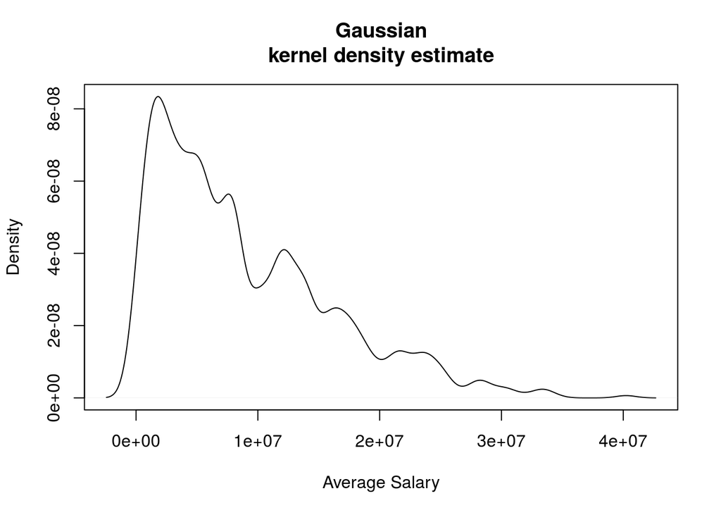

```r
plot(density(df$average.salary,bw="SJ",kern="gaussian"),type="l",main="Gaussian
kernel density estimate",xlab="Average Salary")
```

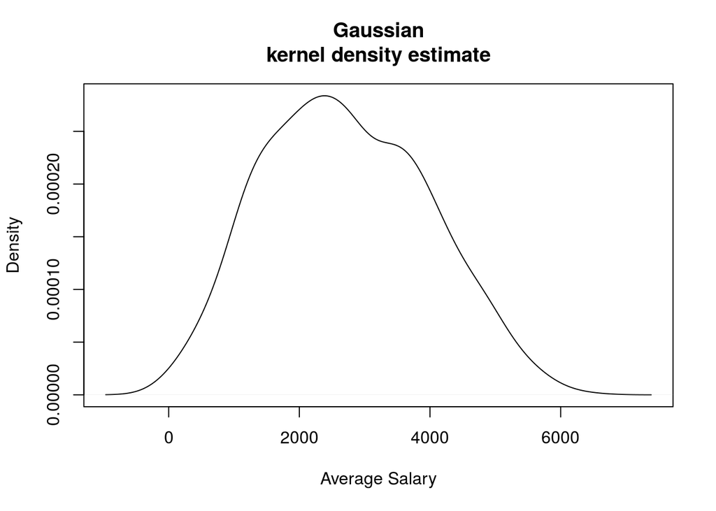

```r
plot(density(sqrt(df$average.salary),bw="SJ",kern="gaussian"),type="l",main="Gaussian
kernel density estimate",xlab="Average Salary")
```

This appears to be approximately normal.

We will have to transform it to match a normal distribution.

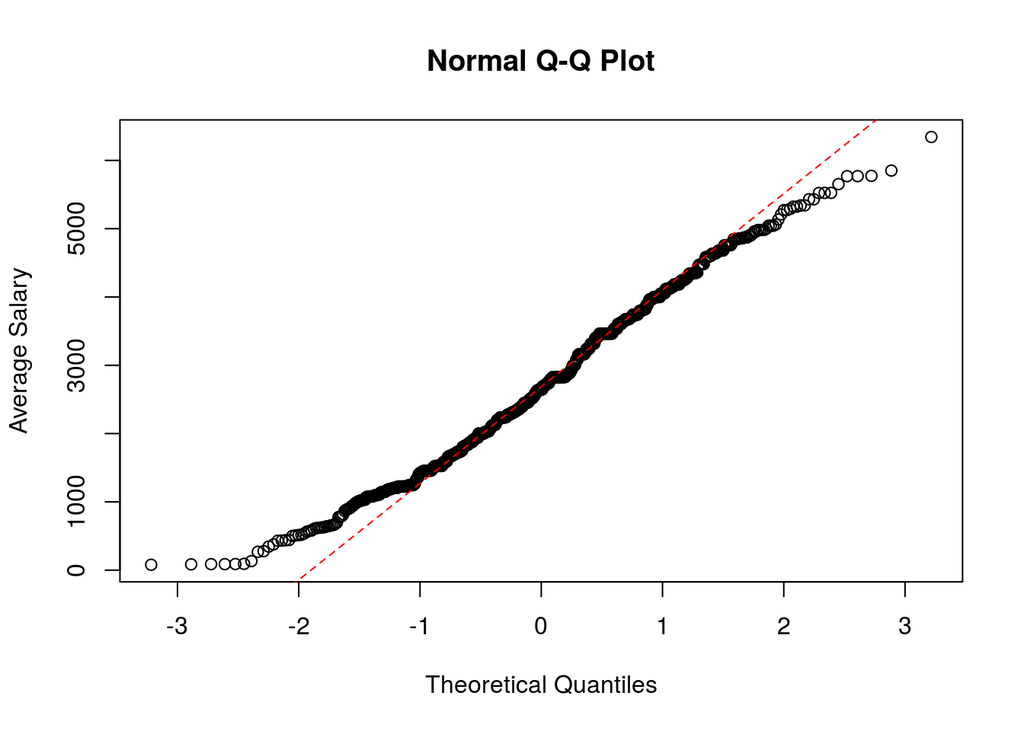

```r
qqnorm(sqrt(df$average.salary), ylab = "Average Salary")
qqline(sqrt(df$average.salary), lty = 2, col = 2)
```

We shall stick with sqrt approximation

Load Libraries

```r
library(leaps)
library(car)
```

Let’s look at everything

```r
jumbo <- lm(average.salary ~ FG + PS.G + FGA + MP + FTA + FT + WS + VORP + TOV + PER + OWS + DRB + GS + BPM + OBPM + DWS + USG. + TRB + STL + WS.48 + AST + PF + ORB + TS. + AST. + BLK + FG. + G + DRB. + eFG. + FTr + DBPM + TRB. + FT. + STL. + ORB. + BLK. + TOV. + factor(Tm) + factor(Year), data = df)
summary(jumbo)
```

```
##
## Call:
## lm(formula = average.salary ~ FG + PS.G + FGA + MP + FTA + FT +
##     WS + VORP + TOV + PER + OWS + DRB + GS + BPM + OBPM + DWS +
##     USG. + TRB + STL + WS.48 + AST + PF + ORB + TS. + AST. +
##     BLK + FG. + G + DRB. + eFG. + FTr + DBPM + TRB. + FT. + STL. +
##     ORB. + BLK. + TOV. + factor(Tm) + factor(Year), data = df)
##
## Residuals:
##       Min        1Q    Median        3Q       Max
## -18085935  -2684925   -202568   2325104  17917599
##
## Coefficients:
##                   Estimate Std. Error t value Pr(>|t|)
## (Intercept)       13707844    8253347   1.661  0.09719 .
## FG                 2388382    1748430   1.366  0.17237
## PS.G                298376     942139   0.317  0.75157
## FGA                -587556     808235  -0.727  0.46749
## MP                   -1661     154397  -0.011  0.99142
## FTA                1725602    1259550   1.370  0.17112
## FT                -1748913    1690244  -1.035  0.30116
## WS                 5168024    3496438   1.478  0.13984
## VORP              -1825715     784919  -2.326  0.02030 *
## TOV                 -32563    1342944  -0.024  0.98066
## PER               -1120996     589212  -1.903  0.05751 .
## OWS               -4342503    3483244  -1.247  0.21293
## DRB               -3883234    3575272  -1.086  0.27779
## GS                   13155      10905   1.206  0.22810
## BPM               -5889569    3650523  -1.613  0.10712
## OBPM               7614595    3649517   2.086  0.03730 *
## DWS               -3304124    3497430  -0.945  0.34512
## USG.                129526     274840   0.471  0.63759
## TRB                4522786    3473586   1.302  0.19333
## STL               -2228359    2082808  -1.070  0.28504
## WS.48             -5059735   29909583  -0.169  0.86571
## AST                1337777     679394   1.969  0.04934 *
## PF                -1890772     615971  -3.070  0.00223 **
## ORB               -5572473    3505106  -1.590  0.11233
## TS.                4246031   30434903   0.140  0.88909
## AST.               -131094     126680  -1.035  0.30110
```

[output cut: 38 more lines]

```
## factor(Tm)SAC     -2337926    1517927  -1.540  0.12396
## factor(Tm)SAS       -81677    1382298  -0.059  0.95290
## factor(Tm)TOR      1383308    1474694   0.938  0.34855
## factor(Tm)TOT      -307816    1208331  -0.255  0.79900
## factor(Tm)UTA       944980    1573528   0.601  0.54834
## factor(Tm)WAS      -347391    1355007  -0.256  0.79774
## factor(Year)2015    903796     493381   1.832  0.06740 .
## factor(Year)2016   3378231     498612   6.775 2.64e-11 ***
## factor(Year)2017   4950828     586111   8.447  < 2e-16 ***
## ---
## Signif. codes:  0 '***' 0.001 '**' 0.01 '*' 0.05 '.' 0.1 ' ' 1
##
## Residual standard error: 4560000 on 699 degrees of freedom
## Multiple R-squared:  0.6458, Adjusted R-squared:  0.6093
## F-statistic:  17.7 on 72 and 699 DF,  p-value: < 2.2e-16
```

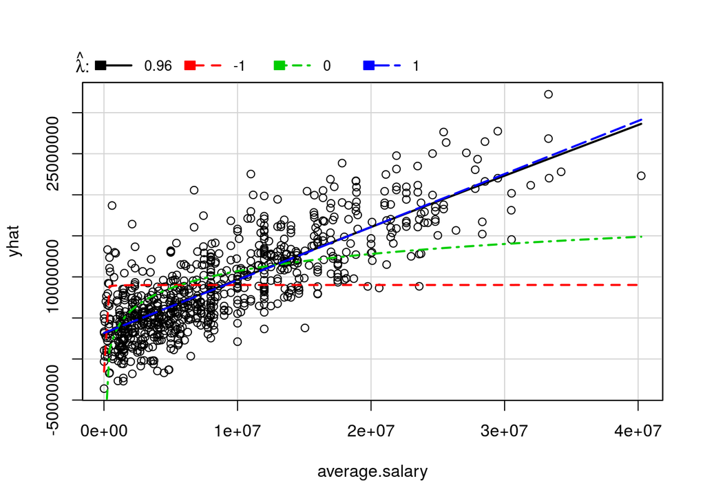

```
##       lambda          RSS
## 1  0.9630257 9.382661e+15
## 2 -1.0000000 2.602587e+16
## 3  0.0000000 1.578593e+16
## 4  1.0000000 9.387650e+15
```

```r
inverseResponsePlot(jumbo)
```

```r
summary(powerTransform(jumbo))
```

```
## bcPower Transformation to Normality
##    Est Power Rounded Pwr Wald Lwr bnd Wald Upr Bnd
## Y1    0.4824         0.5         0.43       0.5348
##
## Likelihood ratio tests about transformation parameters
##                            LRT df pval
## LR test, lambda = (0) 479.9414  1    0
## LR test, lambda = (1) 293.0128  1    0
```

# With Transformation

```r
bm <- regsubsets(sqrt(average.salary) ~ FG + PS.G + FGA + MP + FTA + FT + WS + VORP + TOV + PER + OWS + DRB + GS + BPM + OBPM + DWS + USG. + TRB + STL + WS.48 + AST + PF + ORB + TS. + AST. + BLK + FG. + G + DRB. + eFG. + FTr + DBPM + TRB. + FT. + STL. + ORB. + BLK. + TOV. + factor(Year), data = df, nbest=1, nvmax=NULL, force.in=NULL, force.out=NULL,method="exhaustive", really.big = T)
bm.sum <- summary(bm)
res.legend <-subsets(bm, statistic="adjr2", legend = FALSE, min.size = 3, max.size = 12, main = "Adjusted R^2")
```

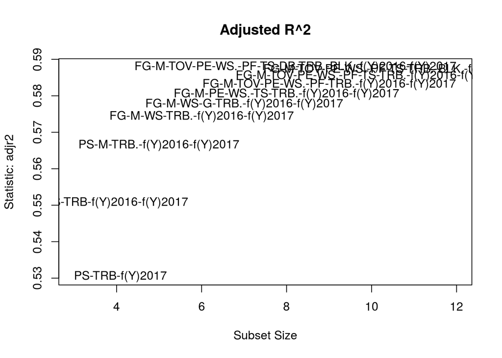

```r
which(bm.sum$which[10,] == TRUE)
```

```
##      (Intercept)               FG               MP              TOV
##                1                2                5               10
##              PER            WS.48               PF              TS.
##               11               21               23               25
##             TRB. factor(Year)2016 factor(Year)2017
##               34               41               42
```

```r
m1 <- lm(sqrt(average.salary) ~ FG + MP + TOV + PER + WS.48 + PF + TS. + TRB. + factor(Year == '2016') + factor(Year == '2017'), data = df)
summary(m1)
```

```
##
## Call:
## lm(formula = sqrt(average.salary) ~ FG + MP + TOV + PER + WS.48 +
##     PF + TS. + TRB. + factor(Year == "2016") + factor(Year ==
##     "2017"), data = df)
##
## Residuals:
##     Min      1Q  Median      3Q     Max
## -4061.9  -449.1    45.4   525.0  2514.0
##
## Coefficients:
##                             Estimate Std. Error t value Pr(>|t|)
## (Intercept)                 1234.964    503.113   2.455 0.014325 *
## FG                           248.301     48.091   5.163 3.10e-07 ***
## MP                            54.638      9.394   5.816 8.86e-09 ***
## TOV                          186.094     67.927   2.740 0.006295 **
## PER                          -93.653     26.209  -3.573 0.000375 ***
## WS.48                       8308.560   1475.592   5.631 2.53e-08 ***
## PF                          -179.422     69.940  -2.565 0.010497 *
## TS.                        -2234.297    958.907  -2.330 0.020064 *
## TRB.                          58.898      8.814   6.683 4.54e-11 ***
## factor(Year == "2016")TRUE   444.309     71.997   6.171 1.10e-09 ***
## factor(Year == "2017")TRUE   767.763     71.479  10.741  < 2e-16 ***
## ---
## Signif. codes:  0 '***' 0.001 '**' 0.01 '*' 0.05 '.' 0.1 ' ' 1
##
## Residual standard error: 801.5 on 761 degrees of freedom
## Multiple R-squared:  0.5909, Adjusted R-squared:  0.5855
## F-statistic: 109.9 on 10 and 761 DF,  p-value: < 2.2e-16
```

```r
vif(m1)
```

```
##                     FG                     MP                    TOV
##              12.205080               5.963351               3.788670
##                    PER                  WS.48                     PF
##              17.564144               7.957362               1.930775
##                    TS.                   TRB. factor(Year == "2016")
##               2.504784               2.066350               1.122358
## factor(Year == "2017")
##               1.167008
```

High VIF for PER and FG, we have to go lower

```r
which(bm.sum$which[9,] == TRUE)
```

```
##      (Intercept)               FG               MP              TOV
##                1                2                5               10
##              PER            WS.48               PF             TRB.
##               11               21               23               34
## factor(Year)2016 factor(Year)2017
##               41               42
```

```r
m2 <- lm(sqrt(average.salary) ~ FG + MP + TOV + PER + WS.48 + PF + TRB. + factor(Year == '2016') + factor(Year == '2017'), data = df)
summary(m2)
```

```
##
## Call:
## lm(formula = sqrt(average.salary) ~ FG + MP + TOV + PER + WS.48 +
##     PF + TRB. + factor(Year == "2016") + factor(Year == "2017"),
##     data = df)
##
## Residuals:
##     Min      1Q  Median      3Q     Max
## -3938.0  -451.7    48.3   536.5  2648.5
##
## Coefficients:
##                            Estimate Std. Error t value Pr(>|t|)
## (Intercept)                 192.924    231.142   0.835 0.404173
## FG                          258.726     48.022   5.388 9.52e-08 ***
## MP                           52.567      9.379   5.605 2.91e-08 ***
## TOV                         214.593     67.011   3.202 0.001420 **
## PER                         -96.172     26.263  -3.662 0.000268 ***
## WS.48                      6728.830   1314.418   5.119 3.89e-07 ***
## PF                         -198.555     69.657  -2.850 0.004484 **
## TRB.                         63.433      8.621   7.358 4.84e-13 ***
## factor(Year == "2016")TRUE  443.994     72.205   6.149 1.26e-09 ***
## factor(Year == "2017")TRUE  739.117     70.618  10.466  < 2e-16 ***
## ---
## Signif. codes:  0 '***' 0.001 '**' 0.01 '*' 0.05 '.' 0.1 ' ' 1
##
## Residual standard error: 803.8 on 762 degrees of freedom
## Multiple R-squared:  0.588,  Adjusted R-squared:  0.5831
## F-statistic: 120.8 on 9 and 762 DF,  p-value: < 2.2e-16
```

```r
vif(m2)
```

```
##                     FG                     MP                    TOV
##              12.099435               5.909955               3.665836
##                    PER                  WS.48                     PF
##              17.534266               6.277498               1.904160
##                   TRB. factor(Year == "2016") factor(Year == "2017")
##               1.965576               1.122354               1.132482
```

Still high

```r
which(bm.sum$which[8,] == TRUE)
```

```
##      (Intercept)               FG               MP              PER
##                1                2                5               11
##            WS.48              TS.             TRB. factor(Year)2016
##               21               25               34               41
## factor(Year)2017
##               42
```

```r
m3 <- lm(sqrt(average.salary) ~ FG + MP + PER + WS.48 +TS. + TRB. + factor(Year == '2016') + factor(Year == '2017'), data = df)
summary(m3)
```

```
##
## Call:
## lm(formula = sqrt(average.salary) ~ FG + MP + PER + WS.48 + TS. +
##     TRB. + factor(Year == "2016") + factor(Year == "2017"), data = df)
##
## Residuals:
##     Min      1Q  Median      3Q     Max
## -4050.3  -453.0    54.8   529.7  2509.8
##
## Coefficients:
##                             Estimate Std. Error t value Pr(>|t|)
## (Intercept)                 1216.586    505.984   2.404  0.01644 *
## FG                           241.198     48.138   5.011 6.75e-07 ***
## MP                            55.624      8.250   6.743 3.07e-11 ***
## PER                          -59.618     23.285  -2.560  0.01065 *
## WS.48                       7374.433   1417.837   5.201 2.55e-07 ***
## TS.                        -2843.834    946.245  -3.005  0.00274 **
## TRB.                          43.698      7.416   5.892 5.71e-09 ***
## factor(Year == "2016")TRUE   448.057     72.415   6.187 9.98e-10 ***
## factor(Year == "2017")TRUE   773.166     71.762  10.774  < 2e-16 ***
## ---
## Signif. codes:  0 '***' 0.001 '**' 0.01 '*' 0.05 '.' 0.1 ' ' 1
##
## Residual standard error: 806.3 on 763 degrees of freedom
## Multiple R-squared:  0.5849, Adjusted R-squared:  0.5805
## F-statistic: 134.4 on 8 and 763 DF,  p-value: < 2.2e-16
```

```r
vif(m3)
```

```
##                     FG                     MP                    PER
##              12.082874               4.544196              13.698039
##                  WS.48                    TS.                   TRB.
##               7.258883               2.409930               1.445508
## factor(Year == "2016") factor(Year == "2017")
##               1.121885               1.162211
```

Still bad.

```r
which(bm.sum$which[7,] == TRUE)
```

```
##      (Intercept)               FG               MP               WS
##                1                2                5                8
##                G             TRB. factor(Year)2016 factor(Year)2017
##               29               34               41               42
```

```r
m4 <- lm(sqrt(average.salary) ~ FG + MP + WS + G + TRB. + factor(Year == '2016') + factor(Year == '2017'), data = df)
summary(m4)
```

```
##
## Call:
## lm(formula = sqrt(average.salary) ~ FG + MP + WS + G + TRB. +
##     factor(Year == "2016") + factor(Year == "2017"), data = df)
##
## Residuals:
##     Min      1Q  Median      3Q     Max
## -4155.5  -467.3    67.3   523.2  2501.4
##
## Coefficients:
##                            Estimate Std. Error t value Pr(>|t|)
## (Intercept)                  54.313    195.758   0.277  0.78151
## FG                          139.689     28.740   4.860 1.42e-06 ***
## MP                           57.963      7.689   7.539 1.35e-13 ***
## WS                           76.492     15.522   4.928 1.02e-06 ***
## G                            -6.602      2.465  -2.678  0.00756 **
## TRB.                         42.469      6.620   6.415 2.47e-10 ***
## factor(Year == "2016")TRUE  457.601     72.600   6.303 4.93e-10 ***
## factor(Year == "2017")TRUE  750.100     70.781  10.598  < 2e-16 ***
## ---
## Signif. codes:  0 '***' 0.001 '**' 0.01 '*' 0.05 '.' 0.1 ' ' 1
##
## Residual standard error: 809 on 764 degrees of freedom
## Multiple R-squared:  0.5816, Adjusted R-squared:  0.5777
## F-statistic: 151.7 on 7 and 764 DF,  p-value: < 2.2e-16
```

```r
vif(m4)
```

```
##                     FG                     MP                     WS
##               4.278568               3.921496               2.832192
##                      G                   TRB. factor(Year == "2016")
##               1.441090               1.144448               1.120245
## factor(Year == "2017")
##               1.123243
```

and bingo was his name-o.

Let’s check model diagnostics

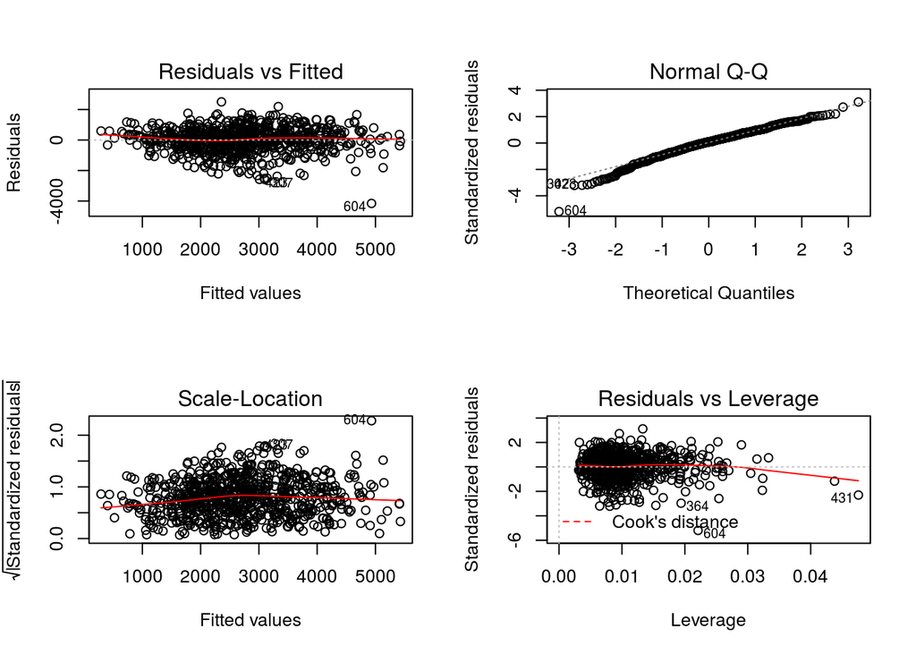

```r
par(mfrow=c(2,2))
plot(m4)
```

I’m going to need new underwear…

# Let’s do without transformation

```r
bm2 <- regsubsets(average.salary ~ FG + PS.G + FGA + MP + FTA + FT + WS + VORP + TOV + PER + OWS + DRB + GS + BPM + OBPM + DWS + USG. + TRB + STL + WS.48 + AST + PF + ORB + TS. + AST. + BLK + FG. + G + DRB. + eFG. + FTr + DBPM + TRB. + FT. + STL. + ORB. + BLK. + TOV. + factor(Year), data = df, nbest=1, nvmax=NULL, force.in=NULL, force.out=NULL,method="exhaustive", really.big = T)
bm2.sum <- summary(bm2)
res.legend <-subsets(bm2, statistic="adjr2", legend = FALSE, min.size = 3, max.size = 12, main = "Adjusted R^2")
```

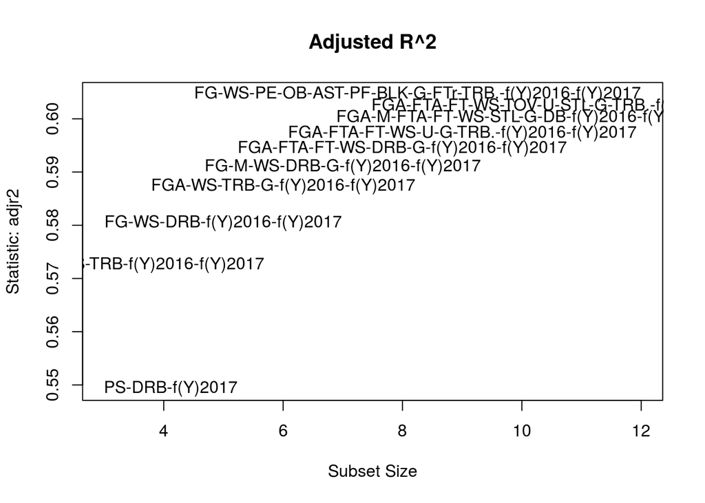

```r
which(bm.sum$which[7,] == TRUE)
```

```
##      (Intercept)               FG               MP               WS
##                1                2                5                8
##                G             TRB. factor(Year)2016 factor(Year)2017
##               29               34               41               42
```

```r
n1 <- lm(average.salary ~ FG + MP + WS + G + TS. + TRB. + factor(Year == "2016") + factor(Year == "2017"), data = df)
summary(n1)
```

```
##
## Call:
## lm(formula = average.salary ~ FG + MP + WS + G + TS. + TRB. +
##     factor(Year == "2016") + factor(Year == "2017"), data = df)
##
## Residuals:
##       Min        1Q    Median        3Q       Max
## -22713336  -2855248    -33102   2563723  18421315
##
## Coefficients:
##                            Estimate Std. Error t value Pr(>|t|)
## (Intercept)                 1549323    2615398   0.592   0.5538
## FG                          1057449     166059   6.368 3.31e-10 ***
## MP                           219635      44527   4.933 9.96e-07 ***
## WS                           705755     102896   6.859 1.43e-11 ***
## G                            -64326      14208  -4.527 6.92e-06 ***
## TS.                        -9737214    4398766  -2.214   0.0271 *
## TRB.                         214065      38145   5.612 2.80e-08 ***
## factor(Year == "2016")TRUE  2894710     418310   6.920 9.57e-12 ***
## factor(Year == "2017")TRUE  4639547     411403  11.277  < 2e-16 ***
## ---
## Signif. codes:  0 '***' 0.001 '**' 0.01 '*' 0.05 '.' 0.1 ' ' 1
##
## Residual standard error: 4661000 on 763 degrees of freedom
## Multiple R-squared:  0.5961, Adjusted R-squared:  0.5919
## F-statistic: 140.8 on 8 and 763 DF,  p-value: < 2.2e-16
```

```r
vif(n1)
```

```
##                     FG                     MP                     WS
##               4.302910               3.961549               3.749052
##                      G                    TS.                   TRB.
##               1.442145               1.558489               1.144464
## factor(Year == "2016") factor(Year == "2017")
##               1.120289               1.143087
```

Good. Let’s check diagnostics.

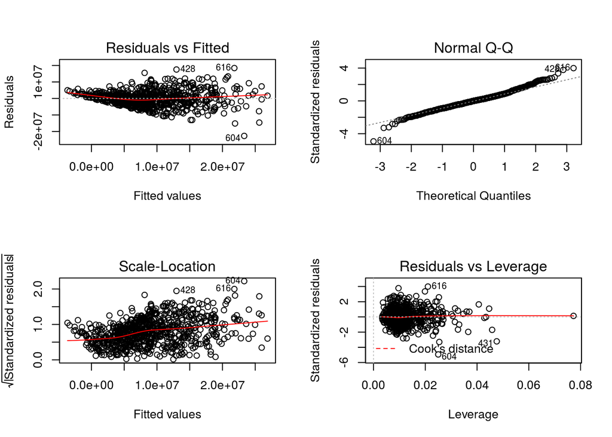

```r
par(mfrow=c(2,2))
plot(n1)
```

Not as valid, we see increasing variance.

# Average Salary by Team

```r
a1 <- aov(average.salary ~ Tm, data = df)
summary(a1)
```

```
##              Df    Sum Sq   Mean Sq F value Pr(>F)
## Tm           31 3.095e+15 9.983e+13   1.947 0.0017 **
## Residuals   740 3.795e+16 5.128e+13
## ---
## Signif. codes:  0 '***' 0.001 '**' 0.01 '*' 0.05 '.' 0.1 ' ' 1
```

```r
require(Hmisc)
summary(average.salary ~ factor(Tm), data = df)
```

```
## average.salary     N= 772
##
## +----------+---+---+--------------+
## |          |   |N  |average.salary|
## +----------+---+---+--------------+
## |factor(Tm)|ATL| 24|10247023      |
## |          |BOS| 21| 8271010      |
## |          |BRK| 24| 7694420      |
## |          |CHA|  4| 7040772      |
## |          |CHI| 24| 8497498      |
## |          |CHO| 16|10978949      |
## |          |CLE| 27|12264847      |
## |          |DAL| 30| 8061347      |
## |          |DEN| 23| 7371964      |
## |          |DET| 20| 7995470      |
## |          |GSW| 31|10070977      |
## |          |HOU| 18|12994907      |
## |          |IND| 28| 8311935      |
## |          |LAC| 37|10591316      |
## |          |LAL| 22| 6543210      |
## |          |MEM| 29|10348104      |
## |          |MIA| 29|11835008      |
## |          |MIL| 19| 8394462      |
## |          |MIN| 15| 6378563      |
## |          |NOP| 29| 8187125      |
## |          |NYK| 26| 8863784      |
## |          |OKC| 20|12261625      |
## |          |ORL| 14| 7531821      |
## |          |PHI|  2| 4604059      |
## |          |PHO| 17| 8945095      |
## |          |POR| 23|10254728      |
## |          |SAC| 22| 6951695      |
## |          |SAS| 31| 9102135      |
## |          |TOR| 25|11144813      |
## |          |TOT| 79| 5430521      |
## |          |UTA| 17|10085319      |
## |          |WAS| 26| 8929652      |
## +----------+---+---+--------------+
## |Overall   |   |772| 8924503      |
## +----------+---+---+--------------+
```

```r
#library(DescTools)
#PostHocTest(aov(average.salary~factor(Tm), data = df),method="lsd")
```

```r
summary(lm(average.salary ~ factor(Tm), df))
```

```
##
## Call:
## lm(formula = average.salary ~ factor(Tm), data = df)
##
## Residuals:
##       Min        1Q    Median        3Q       Max
## -12122850  -5199157  -1483052   4135153  30160781
##
## Coefficients:
##               Estimate Std. Error t value Pr(>|t|)
## (Intercept)   10247023    1461708   7.010 5.36e-12 ***
## factor(Tm)BOS -1976012    2139721  -0.923  0.35605
## factor(Tm)BRK -2552603    2067167  -1.235  0.21729
## factor(Tm)CHA -3206251    3867315  -0.829  0.40734
## factor(Tm)CHI -1749525    2067167  -0.846  0.39764
## factor(Tm)CHO   731926    2311163   0.317  0.75157
## factor(Tm)CLE  2017825    2008925   1.004  0.31550
## factor(Tm)DAL -2185675    1961087  -1.115  0.26542
## factor(Tm)DEN -2875059    2089515  -1.376  0.16925
## factor(Tm)DET -2251553    2168063  -1.039  0.29937
## factor(Tm)GSW  -176046    1946978  -0.090  0.92798
## factor(Tm)HOU  2747884    2232795   1.231  0.21883
## factor(Tm)IND -1935087    1991972  -0.971  0.33165
## factor(Tm)LAC   344294    1876828   0.183  0.85450
## factor(Tm)LAL -3703812    2113626  -1.752  0.08013 .
## factor(Tm)MEM   101081    1976057   0.051  0.95922
## factor(Tm)MIA  1587986    1976057   0.804  0.42188
## factor(Tm)MIL -1852560    2198963  -0.842  0.39980
## factor(Tm)MIN -3868460    2356933  -1.641  0.10116
## factor(Tm)NOP -2059897    1976057  -1.042  0.29755
## factor(Tm)NYK -1383238    2027024  -0.682  0.49520
## factor(Tm)OKC  2014602    2168063   0.929  0.35308
## factor(Tm)ORL -2715202    2408176  -1.127  0.25990
## factor(Tm)PHI -5642964    5270262  -1.071  0.28465
## factor(Tm)PHO -1301928    2270011  -0.574  0.56646
## factor(Tm)POR     7705    2089515   0.004  0.99706
## factor(Tm)SAC -3295328    2113626  -1.559  0.11940
## factor(Tm)SAS -1144888    1946978  -0.588  0.55669
## factor(Tm)TOR   897791    2046391   0.439  0.66099
## factor(Tm)TOT -4816502    1669036  -2.886  0.00402 **
## factor(Tm)UTA  -161703    2270011  -0.071  0.94323
## factor(Tm)WAS -1317371    2027024  -0.650  0.51596
## ---
## Signif. codes:  0 '***' 0.001 '**' 0.01 '*' 0.05 '.' 0.1 ' ' 1
##
## Residual standard error: 7161000 on 740 degrees of freedom
## Multiple R-squared:  0.07541,    Adjusted R-squared:  0.03667
## F-statistic: 1.947 on 31 and 740 DF,  p-value: 0.001702
```

Even with this, adding the team into the model did not prove significant enough to add in.

```r
withTeams <- lm(sqrt(average.salary) ~ FG + MP + WS + G + TRB. + factor(Year == '2016') + factor(Year == '2017') + factor(Tm), data = df)
summary(withTeams)
```

```
##
## Call:
## lm(formula = sqrt(average.salary) ~ FG + MP + WS + G + TRB. +
##     factor(Year == "2016") + factor(Year == "2017") + factor(Tm),
##     data = df)
##
## Residuals:
##     Min      1Q  Median      3Q     Max
## -3730.1  -446.9    44.0   527.3  2328.2
##
## Coefficients:
##                            Estimate Std. Error t value Pr(>|t|)
## (Intercept)                -140.718    262.237  -0.537  0.59170
## FG                          145.650     29.265   4.977 8.06e-07 ***
## MP                           64.579      8.069   8.003 4.74e-15 ***
## WS                           49.173     17.235   2.853  0.00445 **
## G                            -6.444      2.525  -2.552  0.01090 *
## TRB.                         46.028      6.720   6.849 1.57e-11 ***
## factor(Year == "2016")TRUE  445.781     73.604   6.056 2.22e-09 ***
## factor(Year == "2017")TRUE  729.510     71.918  10.144  < 2e-16 ***
## factor(Tm)BOS               -14.110    242.684  -0.058  0.95365
## factor(Tm)BRK               -87.859    236.229  -0.372  0.71006
## factor(Tm)CHA              -185.708    437.508  -0.424  0.67135
## factor(Tm)CHI              -166.288    233.628  -0.712  0.47684
## factor(Tm)CHO               201.515    262.100   0.769  0.44223
## factor(Tm)CLE               357.848    227.386   1.574  0.11598
## factor(Tm)DAL                51.322    222.330   0.231  0.81751
## factor(Tm)DEN              -108.384    237.070  -0.457  0.64768
## factor(Tm)DET               -15.029    246.769  -0.061  0.95145
## factor(Tm)GSW               237.245    222.855   1.065  0.28742
## factor(Tm)HOU               114.032    252.639   0.451  0.65186
## factor(Tm)IND               159.359    225.741   0.706  0.48045
## factor(Tm)LAC               254.984    212.849   1.198  0.23132
## factor(Tm)LAL               -93.325    242.258  -0.385  0.70018
## factor(Tm)MEM               218.905    223.456   0.980  0.32759
## factor(Tm)MIA               200.470    223.772   0.896  0.37062
## factor(Tm)MIL               316.498    249.949   1.266  0.20583
## factor(Tm)MIN              -260.228    267.262  -0.974  0.33054
## factor(Tm)NOP               -44.988    225.163  -0.200  0.84169
## factor(Tm)NYK              -153.012    230.859  -0.663  0.50767
## factor(Tm)OKC               203.791    247.300   0.824  0.41017
## factor(Tm)ORL                87.838    274.570   0.320  0.74913
## factor(Tm)PHI              -118.735    598.135  -0.199  0.84270
## factor(Tm)PHO               -20.164    257.083  -0.078  0.93751
## factor(Tm)POR               283.245    236.307   1.199  0.23106
## factor(Tm)SAC              -354.266    240.773  -1.471  0.14162
## factor(Tm)SAS               303.921    221.574   1.372  0.17059
## factor(Tm)TOR               322.417    231.177   1.395  0.16354
## factor(Tm)TOT               -18.762    191.197  -0.098  0.92186
## factor(Tm)UTA               264.451    257.302   1.028  0.30439
## factor(Tm)WAS                48.110    229.527   0.210  0.83404
## ---
## Signif. codes:  0 '***' 0.001 '**' 0.01 '*' 0.05 '.' 0.1 ' ' 1
##
## Residual standard error: 807.6 on 733 degrees of freedom
## Multiple R-squared:  0.5999, Adjusted R-squared:  0.5792
## F-statistic: 28.92 on 38 and 733 DF,  p-value: < 2.2e-16
```

```r
vif(withTeams)
```

```
##                            GVIF Df GVIF^(1/(2*Df))
## FG                     4.451577  1        2.109876
## MP                     4.333534  1        2.081714
## WS                     3.503580  1        1.871785
## G                      1.517155  1        1.231729
## TRB.                   1.183221  1        1.087760
## factor(Year == "2016") 1.155385  1        1.074888
## factor(Year == "2017") 1.163603  1        1.078704
## factor(Tm)             1.638725 31        1.007998
```

adding what their team is does not prove significant.

# Ridge Regression

“Important” coefficients are large in value, Ridge Regression requires that the predictors be standardized to have SD=1 before beginning this is because they react to units of measurement, since large numbers will play a bigger role.

# The Lasso

Ridge regression has a disadvantage of including all predictors in the final model. The Lasso shrinks the coefficient estimates toward zero but also forces some coefficient estimates to be exactly zero when lambda is lare. This yield models with only a subset of the variables. Selecting the correct value of lambda is critical.

# Principal Components Regression

Popular approach for deriving a low-dimensional set of features from a large set of variables.

```r
#install.packages("pls")
library(ggplot2)
library(ISLR)
library(readr)
```

```r
nba.t=transform(df,sqSal=sqrt(average.salary))
nba.t=subset(nba.t,select=-c(average.salary,fix,Tm,Pos))
head(nba.t)
```

```
##    G GS   MP  FG  FGA   FG.  eFG.  FT FTA   FT. ORB DRB  TRB AST STL BLK
## 1 73 73 35.0 6.4 13.8 0.459 0.522 3.8 4.6 0.815 0.4 3.2  3.6 3.4 0.5 0.0
## 2 56 30 17.0 2.4  4.4 0.546 0.546 1.0 1.2 0.836 1.7 3.3  4.9 0.7 0.4 0.8
## 3 69 69 36.2 9.4 20.6 0.458 0.459 4.3 5.2 0.822 2.4 8.7 11.1 2.6 0.9 1.0
## 4 55 28 23.2 3.7  7.5 0.494 0.507 1.4 2.2 0.628 1.4 2.3  3.8 1.7 1.6 0.3
## 5 72  0 19.4 2.5  3.8 0.644 0.649 1.7 2.3 0.710 1.8 3.5  5.3 0.3 0.4 1.3
## 6 78 26 22.7 2.5  6.2 0.400 0.487 1.2 1.5 0.780 0.5 1.7  2.2 1.0 0.6 0.1
##   TOV  PF PS.G  PER   TS.   FTr ORB. DRB. TRB. AST. STL. BLK. TOV. USG.
## 1 2.0 1.9 18.2 16.0 0.574 0.332  1.4 10.2  5.8 16.9  0.7  0.1 11.2 23.3
## 2 1.1 3.3  5.9 14.6 0.589 0.269 11.3 22.7 16.9  6.6  1.3  4.1 18.4 16.3
## 3 1.8 2.1 23.2 21.8 0.507 0.253  7.2 25.5 16.5 13.0  1.3  1.9  7.2 29.8
## 4 1.6 2.2  9.0 15.6 0.531 0.293  7.3 12.0  9.6 11.7  3.8  1.2 16.2 20.1
## 5 0.7 2.3  6.6 18.5 0.683 0.615 12.1 21.7 17.1  2.1  1.2  6.1 13.2 13.8
## 6 0.8 1.9  7.2  9.5 0.525 0.243  2.7  9.1  5.9  7.3  1.4  0.5 10.4 15.9
##   OWS DWS  WS WS.48 OBPM DBPM  BPM VORP Year     sqSal
## 1 4.3 1.0 5.3 0.099  1.7 -2.3 -0.6  0.9 2014 2709.7048
## 2 1.2 0.9 2.1 0.104 -1.5  0.8 -0.7  0.3 2014  899.1563
## 3 4.0 3.5 7.5 0.144 -0.4  0.7  0.3  1.5 2014 3605.5513
## 4 0.5 2.1 2.7 0.100 -0.1  2.4  2.3  1.4 2014 2236.0680
## 5 3.8 2.2 6.0 0.205  0.1  1.5  1.6  1.3 2014 2277.6084
## 6 0.8 0.9 1.7 0.047 -0.8 -1.4 -2.2 -0.1 2014 1142.2666
```

```r
attach(nba.t)
```

```r
X = nba.t[,-c(40)]
head(X)
```

```
##    G GS   MP  FG  FGA   FG.  eFG.  FT FTA   FT. ORB DRB  TRB AST STL BLK
## 1 73 73 35.0 6.4 13.8 0.459 0.522 3.8 4.6 0.815 0.4 3.2  3.6 3.4 0.5 0.0
## 2 56 30 17.0 2.4  4.4 0.546 0.546 1.0 1.2 0.836 1.7 3.3  4.9 0.7 0.4 0.8
## 3 69 69 36.2 9.4 20.6 0.458 0.459 4.3 5.2 0.822 2.4 8.7 11.1 2.6 0.9 1.0
## 4 55 28 23.2 3.7  7.5 0.494 0.507 1.4 2.2 0.628 1.4 2.3  3.8 1.7 1.6 0.3
## 5 72  0 19.4 2.5  3.8 0.644 0.649 1.7 2.3 0.710 1.8 3.5  5.3 0.3 0.4 1.3
## 6 78 26 22.7 2.5  6.2 0.400 0.487 1.2 1.5 0.780 0.5 1.7  2.2 1.0 0.6 0.1
##   TOV  PF PS.G  PER   TS.   FTr ORB. DRB. TRB. AST. STL. BLK. TOV. USG.
## 1 2.0 1.9 18.2 16.0 0.574 0.332  1.4 10.2  5.8 16.9  0.7  0.1 11.2 23.3
## 2 1.1 3.3  5.9 14.6 0.589 0.269 11.3 22.7 16.9  6.6  1.3  4.1 18.4 16.3
## 3 1.8 2.1 23.2 21.8 0.507 0.253  7.2 25.5 16.5 13.0  1.3  1.9  7.2 29.8
## 4 1.6 2.2  9.0 15.6 0.531 0.293  7.3 12.0  9.6 11.7  3.8  1.2 16.2 20.1
## 5 0.7 2.3  6.6 18.5 0.683 0.615 12.1 21.7 17.1  2.1  1.2  6.1 13.2 13.8
## 6 0.8 1.9  7.2  9.5 0.525 0.243  2.7  9.1  5.9  7.3  1.4  0.5 10.4 15.9
##   OWS DWS  WS WS.48 OBPM DBPM  BPM VORP Year
## 1 4.3 1.0 5.3 0.099  1.7 -2.3 -0.6  0.9 2014
## 2 1.2 0.9 2.1 0.104 -1.5  0.8 -0.7  0.3 2014
## 3 4.0 3.5 7.5 0.144 -0.4  0.7  0.3  1.5 2014
## 4 0.5 2.1 2.7 0.100 -0.1  2.4  2.3  1.4 2014
## 5 3.8 2.2 6.0 0.205  0.1  1.5  1.6  1.3 2014
## 6 0.8 0.9 1.7 0.047 -0.8 -1.4 -2.2 -0.1 2014
```

```r
out.pc = princomp(X, cor = F) # does same thing as standardizing variables
summary(out.pc)
```

```
## Importance of components:
##                            Comp.1     Comp.2     Comp.3     Comp.4
## Standard deviation     32.3265957 12.8665150 11.4894287 8.88612528
## Proportion of Variance  0.6890163  0.1091519  0.0870375 0.05206363
## Cumulative Proportion   0.6890163  0.7981682  0.8852057 0.93726933
##                            Comp.5      Comp.6      Comp.7      Comp.8
## Standard deviation     6.81671531 3.686334288 3.674404100 2.587263268
## Proportion of Variance 0.03063796 0.008959814 0.008901914 0.004413578
## Cumulative Proportion  0.96790729 0.976867106 0.985769019 0.990182597
##                             Comp.9     Comp.10     Comp.11      Comp.12
## Standard deviation     2.078310101 1.648668175 1.238382005 1.1675140853
## Proportion of Variance 0.002847936 0.001792157 0.001011157 0.0008987394
## Cumulative Proportion  0.993030533 0.994822690 0.995833848 0.9967325871
##                             Comp.13      Comp.14      Comp.15      Comp.16
## Standard deviation     1.1328674056 0.9683464846 0.9187802645 0.7236414968
## Proportion of Variance 0.0008461896 0.0006182599 0.0005565867 0.0003452681
## Cumulative Proportion  0.9975787767 0.9981970367 0.9987536234 0.9990988915
##                             Comp.17      Comp.18      Comp.19      Comp.20
## Standard deviation     0.6822092266 0.4752478949 0.4143408246 3.808105e-01
## Proportion of Variance 0.0003068631 0.0001489189 0.0001131944 9.561532e-05
## Cumulative Proportion  0.9994057546 0.9995546736 0.9996678680 9.997635e-01
##                             Comp.21      Comp.22      Comp.23      Comp.24
## Standard deviation     3.397107e-01 2.789940e-01 2.082006e-01 1.847225e-01
## Proportion of Variance 7.609005e-05 5.132147e-05 2.858073e-05 2.249828e-05
## Cumulative Proportion  9.998396e-01 9.998909e-01 9.999195e-01 9.999420e-01
##                             Comp.25      Comp.26      Comp.27      Comp.28
## Standard deviation     1.665549e-01 1.217429e-01 1.132854e-01 9.748858e-02
## Proportion of Variance 1.829044e-05 9.772302e-06 8.461690e-06 6.266384e-06
## Cumulative Proportion  9.999603e-01 9.999700e-01 9.999785e-01 9.999848e-01
##                             Comp.29      Comp.30      Comp.31      Comp.32
## Standard deviation     8.404295e-02 7.592937e-02 6.443104e-02 5.379861e-02
## Proportion of Variance 4.657063e-06 3.801274e-06 2.737158e-06 1.908322e-06
## Cumulative Proportion  9.999894e-01 9.999932e-01 9.999960e-01 9.999979e-01
##                             Comp.33      Comp.34      Comp.35      Comp.36
## Standard deviation     2.949922e-02 2.777027e-02 2.730081e-02 2.632676e-02
## Proportion of Variance 5.737606e-07 5.084751e-07 4.914289e-07 4.569877e-07
## Cumulative Proportion  9.999984e-01 9.999990e-01 9.999994e-01 9.999999e-01
##                             Comp.37      Comp.38      Comp.39
## Standard deviation     9.794991e-03 6.326041e-03 4.122497e-03
## Proportion of Variance 6.325832e-08 2.638600e-08 1.120548e-08
## Cumulative Proportion  1.000000e+00 1.000000e+00 1.000000e+00
```

```r
out.pc$loadings
```

```
##
## Loadings:
##       Comp.1 Comp.2 Comp.3 Comp.4 Comp.5 Comp.6 Comp.7 Comp.8 Comp.9
## G     -0.224  0.858 -0.447
## GS    -0.918         0.275  0.209                0.112
## MP    -0.196        -0.132         0.238  0.611 -0.529         0.223
## FG                                 0.111
## FGA          -0.107 -0.139 -0.144  0.259  0.172
## FG.
## eFG.
## FT
## FTA                        -0.107                      -0.109
## FT.
## ORB                                                            0.139
## DRB                        -0.135         0.116         0.124
## TRB                        -0.194         0.141
## AST                 -0.115
## STL
## BLK
## TOV
## PF
## PS.G  -0.131 -0.133 -0.179 -0.240  0.331               -0.133 -0.204
## PER                        -0.365        -0.344        -0.159  0.175
## TS.
## FTr
## ORB.                 0.176 -0.259 -0.140               -0.394  0.622
## DRB.                 0.284 -0.522 -0.230  0.156         0.442 -0.284
## TRB.                 0.229 -0.393 -0.187                       0.156
## AST.         -0.389 -0.612        -0.544                0.261  0.207
## STL.
## BLK.
## TOV.                              -0.456  0.299        -0.667 -0.425
## USG.         -0.155 -0.213 -0.285  0.287         0.574 -0.137
## OWS                                      -0.265 -0.209
## DWS
## WS                         -0.148        -0.273 -0.263        -0.118
## WS.48
## OBPM                -0.106               -0.251 -0.206
## DBPM                              -0.121        -0.140        -0.147
## BPM                        -0.136        -0.267 -0.345        -0.184
```

[output cut: 172 more lines]

```
## SS loadings      1.000   1.000   1.000   1.000   1.000   1.000   1.000
## Proportion Var   0.026   0.026   0.026   0.026   0.026   0.026   0.026
## Cumulative Var   0.410   0.436   0.462   0.487   0.513   0.538   0.564
##                Comp.23 Comp.24 Comp.25 Comp.26 Comp.27 Comp.28 Comp.29
## SS loadings      1.000   1.000   1.000   1.000   1.000   1.000   1.000
## Proportion Var   0.026   0.026   0.026   0.026   0.026   0.026   0.026
## Cumulative Var   0.590   0.615   0.641   0.667   0.692   0.718   0.744
##                Comp.30 Comp.31 Comp.32 Comp.33 Comp.34 Comp.35 Comp.36
## SS loadings      1.000   1.000   1.000   1.000   1.000   1.000   1.000
## Proportion Var   0.026   0.026   0.026   0.026   0.026   0.026   0.026
## Cumulative Var   0.769   0.795   0.821   0.846   0.872   0.897   0.923
##                Comp.37 Comp.38 Comp.39
## SS loadings      1.000   1.000   1.000
## Proportion Var   0.026   0.026   0.026
## Cumulative Var   0.949   0.974   1.000
```

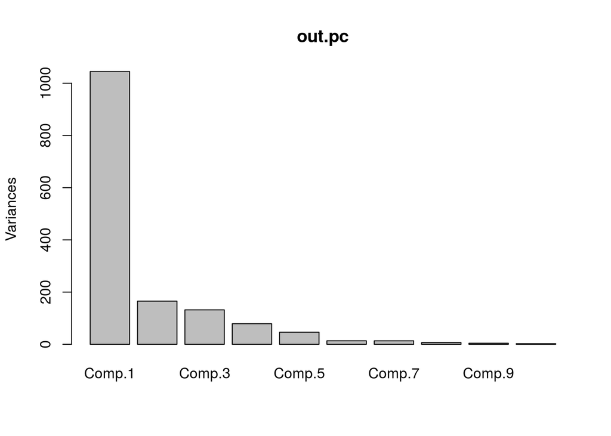

```r
plot(out.pc)
```

```r
set.seed(42) # for cross validation
library(pls)
pcr.fit = pcr(sqSal~., data=nba.t, scale = F, validation = "CV")
summary(pcr.fit)
```

```
## Data:    X dimension: 772 39
##  Y dimension: 772 1
## Fit method: svdpc
## Number of components considered: 39
##
## VALIDATION: RMSEP
## Cross-validated using 10 random segments.
##        (Intercept)  1 comps  2 comps  3 comps  4 comps  5 comps  6 comps
## CV            1246     1008    996.6    994.4    912.2    897.9    892.1
## adjCV         1246     1007    996.3    994.1    911.8    897.4    896.1
##        7 comps  8 comps  9 comps  10 comps  11 comps  12 comps  13 comps
## CV       880.4    880.3    881.2     881.9     881.0     876.9     829.5
## adjCV    879.8    879.7    880.5     881.2     880.1     882.2     828.6
##        14 comps  15 comps  16 comps  17 comps  18 comps  19 comps
## CV        827.5     826.2     827.3     827.8     826.2     823.0
## adjCV     826.3     825.0     826.1     826.6     825.0     821.7
##        20 comps  21 comps  22 comps  23 comps  24 comps  25 comps
## CV        823.6     823.7     824.5     815.2     817.8     818.7
## adjCV     822.3     822.3     823.1     813.7     816.1     816.9
##        26 comps  27 comps  28 comps  29 comps  30 comps  31 comps
## CV        819.2     819.8     821.5     821.4     821.4     822.7
## adjCV     817.4     818.0     819.6     819.5     819.4     820.7
##        32 comps  33 comps  34 comps  35 comps  36 comps  37 comps
## CV        823.7     824.2     823.8     825.4     825.5     826.3
## adjCV     821.5     822.1     821.7     823.1     823.1     823.9
##        38 comps  39 comps
## CV        827.8     828.8
## adjCV     825.3     826.2
##
## TRAINING: % variance explained
##        1 comps  2 comps  3 comps  4 comps  5 comps  6 comps  7 comps
## X        68.90    79.82    88.52    93.73    96.79    97.69    98.58
## sqSal    34.98    36.59    36.94    47.22    48.93    49.49    51.15
##        8 comps  9 comps  10 comps  11 comps  12 comps  13 comps  14 comps
## X        99.02     99.3     99.48     99.58     99.67     99.76     99.82
## sqSal    51.30     51.3     51.30     51.71     51.75     57.37     57.91
##        15 comps  16 comps  17 comps  18 comps  19 comps  20 comps
## X         99.88     99.91     99.94     99.96     99.97     99.98
## sqSal     58.18     58.18     58.21     58.40     58.84     58.87
##        21 comps  22 comps  23 comps  24 comps  25 comps  26 comps
## X         99.98     99.99     99.99     99.99    100.00    100.00
## sqSal     58.91     58.91     60.04     60.06     60.07     60.13
##        27 comps  28 comps  29 comps  30 comps  31 comps  32 comps
## X        100.00    100.00    100.00    100.00    100.00    100.00
## sqSal     60.15     60.15     60.25     60.33     60.34     60.34
##        33 comps  34 comps  35 comps  36 comps  37 comps  38 comps
## X        100.00    100.00    100.00    100.00    100.00    100.00
## sqSal     60.34     60.44     60.55     60.64     60.65     60.68
##        39 comps
## X        100.00
## sqSal     60.69
```

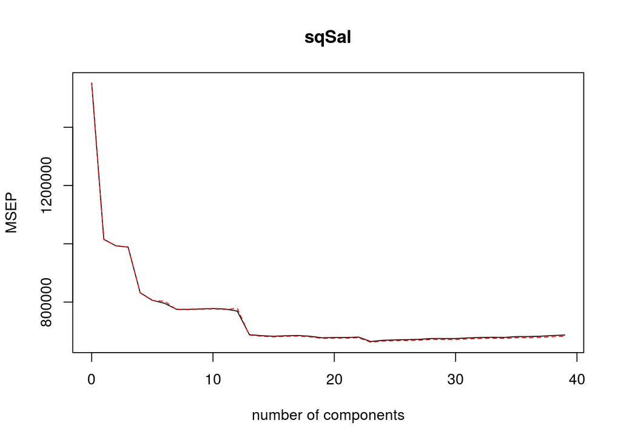

```r
validationplot(pcr.fit, val.type="MSEP")
```

Let’s fit with 9 PCs

```r
pcr.9pc = pcr(sqSal~., data=nba.t, scale = T, ncomp = 9)
summary(pcr.9pc)
```

```
## Data:    X dimension: 772 39
##  Y dimension: 772 1
## Fit method: svdpc
## Number of components considered: 9
## TRAINING: % variance explained
##        1 comps  2 comps  3 comps  4 comps  5 comps  6 comps  7 comps
## X        38.88    59.81    67.53    73.91    78.50    81.54    84.20
## sqSal    46.16    46.19    46.56    48.81    49.66    49.72    55.16
##        8 comps  9 comps
## X        86.63    89.01
## sqSal    55.18    55.62
```